# Bayesian data analysis & cognitive modeling

\[ \definecolor{firebrick}{RGB}{178,34,34} \newcommand{\red}[1]{{\color{firebrick}{#1}}} \] \[ \definecolor{mygray}{RGB}{178,34,34} \newcommand{\mygray}[1]{{\color{mygray}{#1}}} \] \[ \newcommand{\set}[1]{\{#1\}} \] \[ \newcommand{\tuple}[1]{\langle#1\rangle} \] \[\newcommand{\States}{{T}}\] \[\newcommand{\state}{{t}}\] \[\newcommand{\pow}[1]{{\mathcal{P}(#1)}}\]

## key notions

- basics
  - joint distributions & marginalization
  - conditional probability & Bayes rule
- 3 pillars of Bayesian data analysis:
  - estimation
  - comparison
  - prediction
- parameter estimation for coin flips
  - conjugate priors
  - highest density interval

## recap

definition of **conditional probability**:

\[P(X \, | \, Y) = \frac{P(X \cap Y)}{P(Y)}\]

definition of Bayes rule:

\[P(X \, | \, Y) = \frac{P(Y \, | \, X) \ P(X)}{P(Y)}\]

version for data analysis:

\[\underbrace{P(\theta \, | \, D)}_{posterior} \propto \underbrace{P(\theta)}_{prior} \ \underbrace{P(D \, | \, \theta)}_{likelihood}\]

## Bayes rule in multi-D

## proportions of eye & hair color

joint probability distribution as a two-dimensional matrix:

```r
knitr::kable(prob2ds)
```

|  | blond | brown | red | black |
| --- | --- | --- | --- | --- |
| blue | 0.03 | 0.04 | 0.00 | 0.41 |
| green | 0.09 | 0.09 | 0.05 | 0.01 |
| brown | 0.04 | 0.02 | 0.09 | 0.13 |

marginal distribution over eye color:

```r
  rowSums(prob2ds)
```

```
##  blue green brown
##  0.48  0.24  0.28
```

## proportions of eye & hair color

joint probability distribution as a two-dimensional matrix:

```r
prob2ds
```

```
##       blond brown  red black
## blue   0.03  0.04 0.00  0.41
## green  0.09  0.09 0.05  0.01
## brown  0.04  0.02 0.09  0.13
```

conditional probability given blue eyes:

```r
  prob2ds["blue",] %>% (function(x) x/sum(x))
```

```
##      blond      brown        red      black
## 0.06250000 0.08333333 0.00000000 0.85416667
```

## model & data

- single coin flip with unknown success bias \(\theta \in \{0, \frac{1}{3}, \frac{1}{2}, \frac{2}{3}, 1\}\)
- flat prior beliefs: \(P(\theta) = .2\,, \forall \theta\)

model likelihood \(P(D \, | \, \theta)\):

```r
  likelihood
```

```
##      t=0 t=1/3 t=1/2 t=2/3 t=1
## succ   0  0.33   0.5  0.67   1
## fail   1  0.67   0.5  0.33   0
```

weighing in \(P(\theta)\):

```r
  prob2d = likelihood  * 0.2
  prob2d
```

```
##      t=0 t=1/3 t=1/2 t=2/3 t=1
## succ 0.0 0.066   0.1 0.134 0.2
## fail 0.2 0.134   0.1 0.066 0.0
```

back to start: joint-probability distribution as 2d matrix again

## model, data & Bayesian inference

Bayes rule: \(P(\theta \, | \, D) \propto P(\theta) \times P(D \, | \, \theta)\)

```r
  prob2d
```

```
##      t=0 t=1/3 t=1/2 t=2/3 t=1
## succ 0.0 0.066   0.1 0.134 0.2
## fail 0.2 0.134   0.1 0.066 0.0
```

posterior \(P(\theta \, | \, \text{heads})\) after one success:

```r
  prob2d["succ",] %>%
    (function(x) x / sum(x))
```

```
##   t=0 t=1/3 t=1/2 t=2/3   t=1
## 0.000 0.132 0.200 0.268 0.400
```

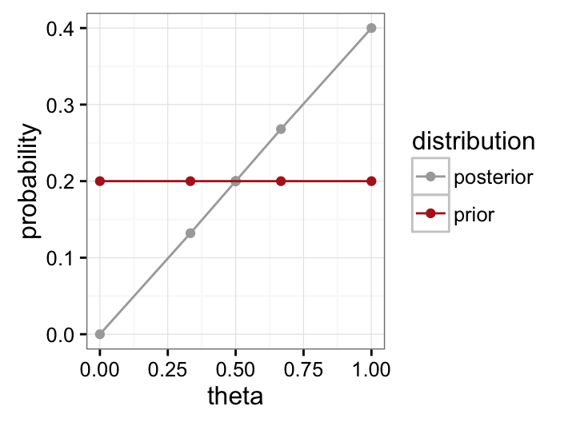

## 3 pillars of BDA

## caveat

this section is for overview and outlook only

we will deal with this in detail later

## estimation

given model and data, which parameter values should we believe in?

\[\underbrace{P(\theta \, | \, D)}_{posterior} \propto \underbrace{P(\theta)}_{prior} \ \underbrace{P(D \, | \, \theta)}_{likelihood}\]

## model comparison

which of two models is more likely, given the data?

\[\underbrace{\frac{P(M_1 \mid D)}{P(M_2 \mid D)}}_{\text{posterior odds}} = \underbrace{\frac{P(D \mid M_1)}{P(D \mid M_2)}}_{\text{Bayes factor}} \ \underbrace{\frac{P(M_1)}{P(M_2)}}_{\text{prior odds}}\]

## prediction

which future observations do we expect (after seeing some data)?

prior predictive

\[ P(D) = \int P(\theta) \ P(D \mid \theta) \ \text{d}\theta \]

posterior predictive

\[ P(D \mid D') = \int P(\theta \mid D') \ P(D \mid \theta) \ \text{d}\theta \]

requires sampling distribution (more on this later)

special case: prior/posterior predictive \(p\)-value (model criticism)

## outlook

- focus on parameter estimation first
- look at computational tools for efficiently calculating posterior \(P(\theta \mid D)\)
- use clever theory to reduce model comparison to parameter estimation

## coin bias estimation

## likelihood function for several tosses

- success is 1; failure is 0
- pair \(\tuple{k,n}\) is an outcome with \(k\) success in \(n\) flips

recap: binomial distribution:

\[ B(k ; n, \theta) = \binom{n}{k} \theta^{k} \, (1-\theta)^{n-k} \]

parameter estimation problem

\[ P(\theta \mid k, n) = \frac{P(\theta) \ B(k ; n, \theta)}{\int P(\theta') \ B(k ; n, \theta') \ \text{d}\theta} \]

hey!?! what about the \(p\)-problems, sampling distributions etc.?

## parameter estimation & normalized likelihoods

claim: estimation of \(P(\theta \mid D)\) is independent of assumptions about sample space and sample procedure

proof

any normalizing constant \(X\) cancels out:

\[ \begin{align*} P(\theta \mid D) & = \frac{P(\theta) \ P(D \mid \theta)}{\int_{\theta'} P(\theta') \ P(D \mid \theta')} \\ & = \frac{ \frac{1}{X} \ P(\theta) \ P(D \mid \theta)}{ \ \frac{1}{X}\ \int_{\theta'} P(\theta') \ P(D \mid \theta')} \\ & = \frac{P(\theta) \ \frac{1}{X}\ P(D \mid \theta)}{ \int_{\theta'} P(\theta') \ \frac{1}{X}\ P(D \mid \theta')} \end{align*} \]

\(\Box\)

## welcome infinity

what if \(\theta\) is allowed to have any value \(\theta \in [0;1]\)?

two problems

1. how to specify \(P(\theta)\) in a concise way?
2. how to compute normalizing constant \(\int_0^1 P(\theta) \ P(D \, | \, \theta) \, \text{d}\theta\)?

one solution

- use beta distribution to specify prior \(P(\theta)\) with some handy parameters
- since this is the conjugate prior to our likelihood function, computing posteriors is as easy as sleep

[figure not shown]

## beta distribution

2 shape parameters \(a, b > 0\), defined over domain \([0;1]\)

\[\text{Beta}(\theta \, | \, a, b) \propto \theta^{a-1} \, (1-\theta)^{b-1}\]

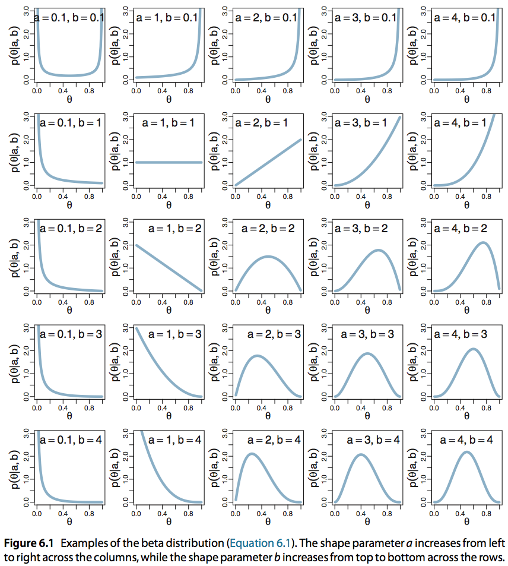

## conjugate distributions

if prior \(P(\theta)\) and posterior \(P(\theta \, | \, D)\) are of the same family, they conjugate, and the prior \(P(\theta)\) is called conjugate prior for the likelihood function \(P(D \, | \, \theta)\) from which the posterior \(P(\theta \, | \, D)\) is derived

claim: the beta distribution is the conjugate prior of a binomial likelihood function

proof

\[ \begin{align*} P(\theta \mid \tuple{k, n}) & \propto B(k ; n, \theta) \ \text{Beta}(\theta \, | \, a, b) \\ P(\theta \mid \tuple{k, n}) & \propto \theta^{k} \, (1-\theta)^{n-k} \, \theta^{a-1} \, (1-\theta)^{b-1} \ \ = \ \ \theta^{k + a - 1} \, (1-\theta)^{n-k +b -1} \\ P(\theta \mid \tuple{k, n}) & = \text{Beta}(\theta \, | \, k + a, n-k + b) \end{align*} \]

\(\Box\)

## example applications

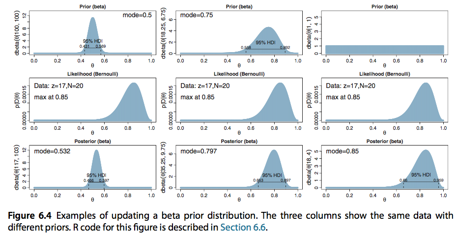

## priors, likelihood & posterior

## Bayes' puppies

posterior is a "compromise" between prior and likelihood

\[\underbrace{P(\theta \, | \, D)}_{posterior} \propto \underbrace{P(\theta)}_{prior} \ \underbrace{P(D \, | \, \theta)}_{likelihood}\]

[figure not shown]

## influence of sample size on posterior

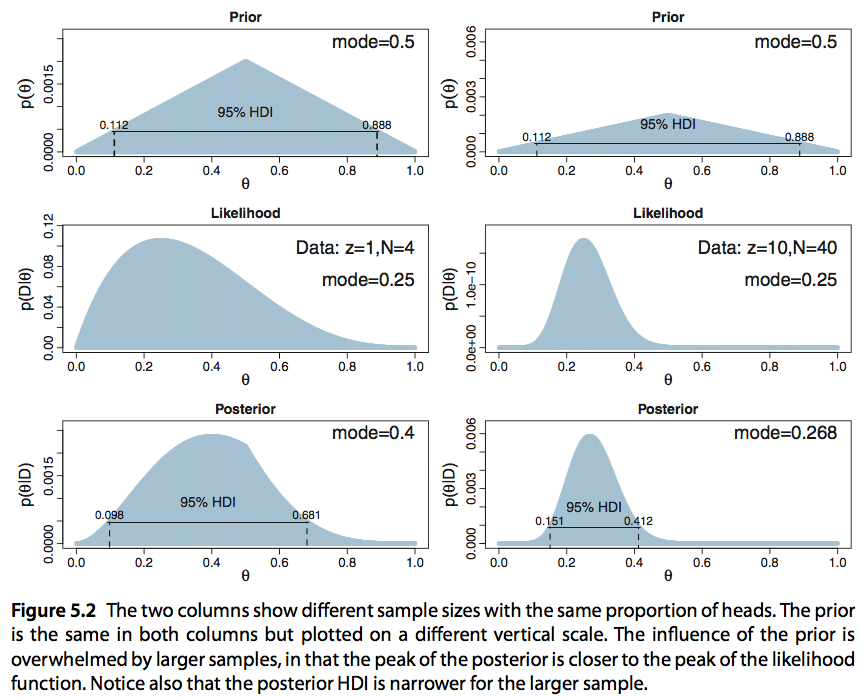

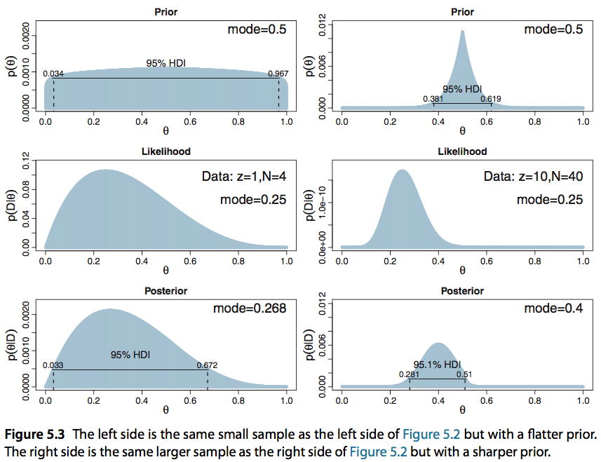

## highest density intervals

## highest density interval

given distribution \(P(\cdot) \in \Delta(X)\), the 95% highest density interval is a subset \(Y \subseteq X\) such that:

1. \(P(Y) = .95\), and
2. no point outside of \(Y\) is more likely than any point within.

Intuition: range of values we are justified to belief in (categorically).

caveat: NOT the same as the 2.5%-97.5% quantile range!!

## examples

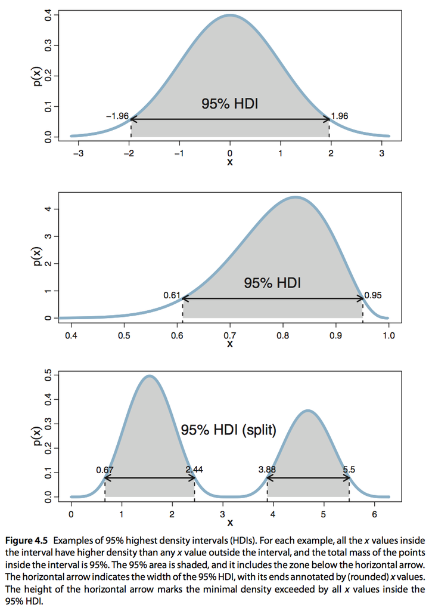

## example

observed: \(k = 7\) successes in \(n = 24\) flips;

prior: \(\theta \sim \text{Beta}(1,1)\)

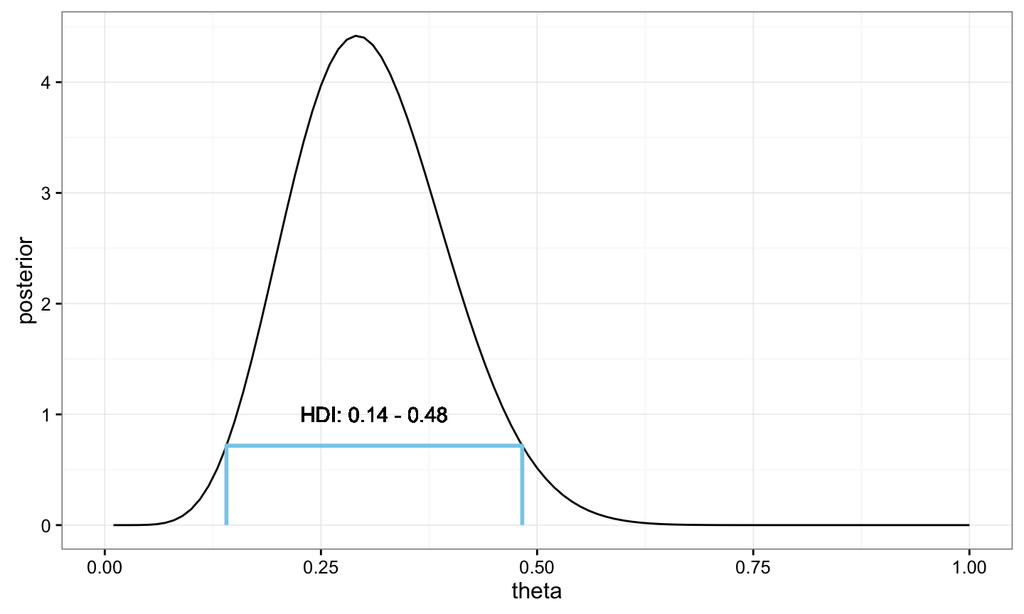

## the road ahead

## BDA more generally

problems:

- conjugate priors are not always available:
  - likelihood functions can come from unbending beasts:
    - complex hierarchical models (e.g., regression)
    - custom-made stuff (e.g., probabilistic grammars)
- even when available, they may not be what we want:
  - prior beliefs could be different from what a conjugate prior can capture

solution:

- approximate posterior distribution by smart numerical simulations

## fini

## outlook

Tuesday

- introduction to MCMC methods

Friday

- introduction to JAGS

## to prevent boredom

obligatory

- prepare Kruschke chapter 7
- finish first homework set: due Friday before class